# Module Seven Activity

For the module seven activity, you will identify relevant data and write Python code to generate visualizations and interpret insights from the provided data set. Professionals in data-driven fields must not only interpret data but also gather, analyze, and present it in meaningful and actionable ways. This activity allows you to practice these essential skills by working through the complete exploratory data analysis (EDA) process.

*Note:* there are two parts to this assignment. Part One is the coding activity. Part Two is the written report.

Once your code is complete, you will download this notebook as an HTML file by clicking **File**, then **Download As**, then **HTML (.html)** from the Jupyter menu bar. Validate that your code, output, and all visualizations (rendered as images using the display() function) are visible in the html file before submission.

*Missing Blocks:* Ensure that you have clicked **Run** for all blocks before downloading as an HTML file or the block may be missing from your submission. **Images** must be called using the *display()* function, for example: **display(Image(filename="output/{image_name}.png"))**

Specifically, you must address the items from the rubric criteria.

### Part One: Python Code

In this part, you will write Python code to analyze the data and generate visualizations that explore trends.

#### Create multiple, distinct visualizations that explore different aspects of the data using Python Libraries.

Include the following:

- Code comments explaining each step of your analysis

### Part Two: Report

In this part, you will write a reflection to explain the insights gained from your analysis and visualizations. *This part is to be completed in a word document, using the output here to answer the topics.*

- Explain the trends, differences, or outliers you observed in the data.
- Describe any disparities or patterns that may be relevant to the nonprofit’s goals.
- Write a summary of what the data suggests about transit usage across neighborhoods.
- Explain how the visualizations support your conclusions.
- Discuss how your findings could inform the nonprofit’s decision-making or strategy.
- Describe the importance of data-driven insights in addressing real-world challenges.

*To Begin:* This Python template program has been broken down into segments as a guide for what steps you should do at a minimum to complete this activity. Look for the **# To Do:** comments. These are placeholders for you to provide Python code segments. Fill out all **# To Do:** code segments to complete this program.  
*Once Complete:* Execute a "Kernel restart and run all" to verify that all your code works as a single unit by clicking **Kernel**, then **Restart & Run All** before downloading as html.

*Hint:* If you need to install additional packages, see one of the earlier modules on how to configure and call a requirements.txt file.

## Import the Required Packages

```python
import pandas as pd
import matplotlib.pyplot as plt
import seaborn as sns
import os
import matplotlib.image as mpimg

from IPython.display import Image, display # for image rendering in html output
```

# Part One: Python Code

*Reminder:* Ensure that you add code comments explaining each step of your analysis.

## Define the file path for the dataset

```python
data_path = "data/Feb_2025_Complete_Monthly_Ridership.csv"
```

## Loading the dataset

```python
# To Do: Load the dataset
df = pd.read_csv(data_path)
```

## Create an output folder if it doesn't already exist

```python
output_folder = "output"
os.makedirs(output_folder, exist_ok=True)
```

## Display Dataset Information

```python
print("Dataset Overview:")
# To Do: Print the first 5 rows of the dataset to inspect the data to ensure it loaded correctly
print(df.head()) # Print first 5 rows
```

```
Dataset Overview:
   NTD ID Legacy NTD ID       Agency Mode TOS 3 Mode
0       1          0001  King County   DR  PT    Bus  \
1       1          0001  King County   DR  TX    Bus
2       1          0001  King County   FB  DO  Ferry
3       1          0001  King County   LR  DO   Rail
4       1          0001  King County   MB  DO    Bus

  Mode/Type of Service Status  Reporter Type
0                      Active  Full Reporter  \
1                      Active  Full Reporter
2                      Active  Full Reporter
3                    Inactive  Full Reporter
4                      Active  Full Reporter

```

[output cut: 36 more lines]

```python
print("Column Names:")
# To Do: Print all column names
print(df.columns)# Print column names
```

```
Column Names:
Index(['NTD ID', 'Legacy NTD ID', 'Agency', 'Mode', 'TOS', '3 Mode',
       'Mode/Type of Service Status', 'Reporter Type', 'Organization Type',
       'HQ City', 'HQ State', 'UACE CD', 'UZA Name', 'UZA SQ Miles',
       'UZA Population', 'Service Area Population', 'Service Area SQ Miles',
       'Last Closed Report Year', 'Last Closed FY End Month',
       'Last Closed FY End Year', 'Passenger Miles FY',
       'Unlinked Passenger Trips FY', 'Avg Trip Length FY', 'Fares FY',
       'Operating Expenses FY', 'Avg Cost Per Trip FY',
       'Avg Fares Per Trip FY'],
      dtype='object')
```

```python
neighborhoods = ["King County", "City of Longview", "Spokane Transit Authority"]
# To Do: Filter the data for the three neighborhoods and create an explicit copy
df_filtered = df[df['Agency'].isin(neighborhoods)].copy()
```

```python
# To Do: Convert numeric columns to proper formats (removing commas and extra spaces)
cols_to_fix = [
    'Unlinked Passenger Trips FY',
    'Fares FY',
    'Operating Expenses FY',
    'Avg Cost Per Trip FY'
]

for col in cols_to_fix:
    # Remove dollar signs, commas, and whitespace, then convert to numeric
    df_filtered[col] = df_filtered[col].astype(str).str.replace(r'[$,]', '', regex=True).str.strip()
    df_filtered[col] = pd.to_numeric(df_filtered[col], errors='coerce')

# Preview the cleaned data
print("Filtered and Cleaned Data:")
print(df_filtered[['Agency', 'Mode', 'Fares FY', 'Operating Expenses FY']].head())
```

```
Filtered and Cleaned Data:
        Agency Mode    Fares FY  Operating Expenses FY
0  King County   DR    816892.0             72095003.0
1  King County   DR    105605.0              5658724.0
2  King County   FB   1493280.0              8625721.0
3  King County   LR    288470.0              2281393.0
4  King County   MB  60386305.0            710359423.0
```

## Generate, Save, and Output Visualizations

*Example Visualizations:* The three visualization placeholders below are example visualization placeholders for the data using a provided template. These are simple example frameworks that you may use, but you may, and are encouraged to develop your own visualizations that you will then explain how the selected visualizations support your conclusions in the part two report.

In accordance with the scenario, three neighborhoods for evaluation are: King County, City of Longview, and Spokane Transit Authority which have been listed in the neighborhoods variable above.

### Visualization 1: Line chart of ridership trends over years

This is an example visualization you can generate. You may implement a chart and assessment of your choosing in lieu of this placeholder.

#### At a minimum include the following actions:

- Add title and axis labels
- Save the plot to a png file in the 'output' folder
- Use the display() function to render the generated png image in the html output
- Comments explaining each step of your analysis

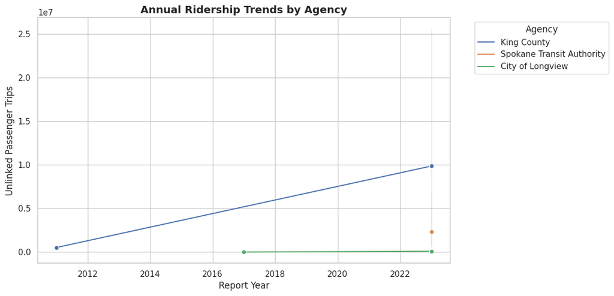

```python
# To Do: Create a visualization that will support your conclusions for part two
plt.figure(figsize=(10, 6))
sns.set_theme(style="whitegrid")

# Create the line plot
# We use 'Last Closed Report Year' for the x-axis as per your column list
line_chart = sns.lineplot(
    data=df_filtered,
    x='Last Closed Report Year',
    y='Unlinked Passenger Trips FY',
    hue='Agency',
    marker='o'
)

# Add title and axis labels
plt.title('Annual Ridership Trends by Agency', fontsize=14, fontweight='bold')
plt.xlabel('Report Year', fontsize=12)
plt.ylabel('Unlinked Passenger Trips', fontsize=12)
plt.legend(title='Agency', bbox_to_anchor=(1.05, 1), loc='upper left')

# Save the plot to a png file in the 'output' folder
output_filename = os.path.join(output_folder, 'ridership_trends.png')
plt.savefig(output_filename, bbox_inches='tight')
plt.close()

# Use the display() function to render the generated png image in the html output
display(Image(filename=output_filename))
```

### Visualization 2: Bar chart comparing total ridership across neighborhoods

This is an example visualization you can generate. You may implement a chart and assessment of your choosing in lieu of this placeholder.

#### At a minimum include the following actions:

- Add title and axis labels
- Save the plot to a png file in the 'output' folder
- Use the display() function to render the generated png image in the html output
- Comments explaining each step of your analysis

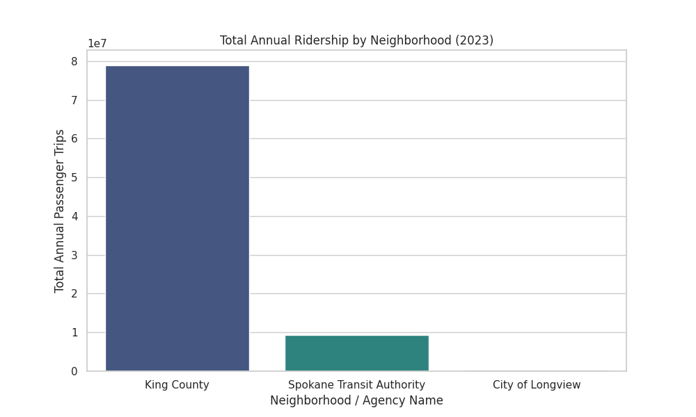

```
Total Ridership Data Used for Visualization:
                      Agency  Unlinked Passenger Trips FY
1                King County                     78886848
2  Spokane Transit Authority                      9403739
0           City of Longview                       274804
```

```python
# To Do: Create a visualization that will support your conclusions for part twolatest_year = df_filtered['Last Closed Report Year'].max()

latest_year = df_filtered['Last Closed Report Year'].max()

# 2. Filter for only the most recent reporting year to compare current transit usage
df_latest = df_filtered[df_filtered['Last Closed Report Year'] == latest_year]

# 3. Group by Agency to aggregate total annual ridership (Unlinked Passenger Trips)
# This sums the ridership across all modes (Bus, Rail, Ferry, etc.) for each neighborhood
ridership_by_neighborhood = df_latest.groupby('Agency')['Unlinked Passenger Trips FY'].sum().reset_index()

# 4. Sort the neighborhoods by ridership for a more readable chart
ridership_by_neighborhood = ridership_by_neighborhood.sort_values(by='Unlinked Passenger Trips FY', ascending=False)

# 5. Create the Bar Chart
plt.figure(figsize=(10, 6))
sns.barplot(data=ridership_by_neighborhood, x='Agency', y='Unlinked Passenger Trips FY', palette='viridis')

# 6. Add title and axis labels
plt.title(f'Total Annual Ridership by Neighborhood ({int(latest_year)})')
plt.xlabel('Neighborhood / Agency Name')
plt.ylabel('Total Annual Passenger Trips')

# 7. Save the plot to a png file in the 'output' folder
plot_filename = 'ridership_comparison.png'
plot_path = os.path.join(output_folder, plot_filename)
plt.savefig(plot_path)


# 8. Use the display() function to render the generated png image
# This ensures the chart appears in your final HTML output
display(Image(filename=plot_path))
plt.close()

# Print data summary to console
print("\nTotal Ridership Data Used for Visualization:")
print(ridership_by_neighborhood)
```

### Visualization 3: Scatterplot of ridership vs population

This is an example visualization you can generate. You may implement a chart and assessment of your choosing in lieu of this placeholder.

#### At a minimum include the following actions:

- Add title and axis labels
- Save the plot to a png file in the 'output' folder
- Use the display() function to render the generated png image in the html output
- Comments explaining each step of your analysis

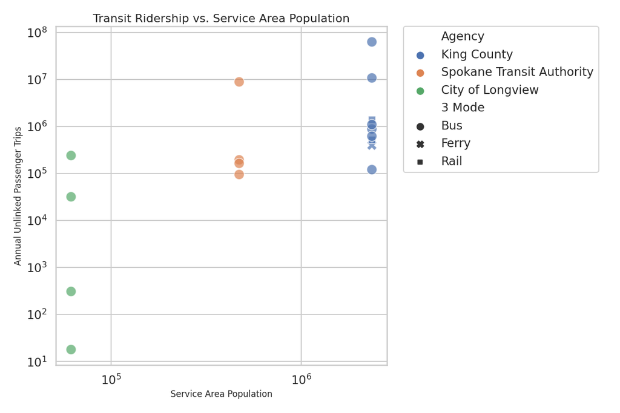

```
Correlation Check (Ridership vs Population):
        Agency  Service Area Population  Unlinked Passenger Trips FY
0  King County                2347800.0                       888663
1  King County                2347800.0                       121496
2  King County                2347800.0                       399687
3  King County                2347800.0                       520933
4  King County                2347800.0                     63485248
```

```python
# To Do: Create a visualization that will support your conclusions for part two

sns.set_context("talk")
plt.figure(figsize=(12, 8))


#'Service Area Population' on the X-axis and 'Unlinked Passenger Trips FY' on the Y-axis
# 'hue' is set to Agency to distinguish between our three neighborhoods
scatter = sns.scatterplot(
    data=df_filtered,
    x='Service Area Population',
    y='Unlinked Passenger Trips FY',
    hue='Agency',
    style='3 Mode', # Different shapes for Bus vs Rail vs Ferry
    s=200,          # Increase marker size for visibility
    alpha=0.7       # Add transparency to see overlapping points
)

# Add title and axis labels
plt.title('Transit Ridership vs. Service Area Population', fontsize=16)
plt.xlabel('Service Area Population', fontsize=12)
plt.ylabel('Annual Unlinked Passenger Trips', fontsize=12)

# Use a log scale if the data range is extreme
plt.xscale('log')
plt.yscale('log')

# Add a legend to identify agencies and modes
plt.legend(bbox_to_anchor=(1.05, 1), loc='upper left', borderaxespad=0.)

# Save the plot to a png file in the 'output' folder
scatter_filename = 'ridership_vs_population.png'
scatter_path = os.path.join(output_folder, scatter_filename)
plt.tight_layout()
plt.savefig(scatter_path)

# 7. Use the display() function to render the generated png image
display(Image(filename=scatter_path))
plt.close()

# data check to ensure values exist for both axes
print("Correlation Check (Ridership vs Population):")
print(df_filtered[['Agency', 'Service Area Population', 'Unlinked Passenger Trips FY']].dropna().head())
```